# Public Finances

Session 2

Luis F. Gómez L.

luis.gomezl@unimilitar.edu.co

Distance Learning Faculty

9 February, 2026

# Please Read Me

- Check the message **Welcome greeting** published in Announcements forum.
- Dear student please edit your profile uploading a photo where your face is clearly visible.
- If you want to participate, please fill out the following survey: **Primer corte 30% > Learning Activities > Tu opinión sobre la economía colombiana**
- This presentation is based on (Cardenas, 2020, Chapter 6)
- **Purpose**
  - Explain the role of the State in the economy

# Expenditures

- Useful resources
  - **Portal de transparencia económica**
  - **Guía ciudadana a la tributación y el gasto del Estado colombiano** (Universidad Javeriana, 2018)
    - [**https://www.ofiscal.org/guias**](https://www.ofiscal.org/guias) > Tributación y gasto del Estado colombiano > Ver guía
  - **Presupuesto en Perspectiva Económica (PePE)**
    - [**https://www.ofiscal.org/interactua**](https://www.ofiscal.org/interactua) > PePE Presupuesto en Perspectiva Económica
- **Presupuesto General de la Nación (PGN)**
  - It is the most important financial management instrument of fiscal policy
  - This instrument presents the government’s proposed revenues and spending for a specific period
  - Every year the “Presupuesto General de la Nación (PGN)” is define for the next year
  - The “Presupuesto General de la Nación (PGN)” must be approved by the congress and sanctioned as a law by the president

Table 1: Classification by sector - PNG

| Sector |
| --- |
| Agricultura Y Desarrollo Rural |
| Ambiente Y Desarrollo Sostenible |
| Ciencia, Tecnología E Innovación |
| Comercio, Industria Y Turismo |
| Congreso De La Republica |
| Cultura |
| Defensa Y Policia |
| Deporte Y Recreacion |
| Educacion |
| Empleo Publico |
| Fiscalia |
| Hacienda |
| Igualdad Y Equidad |
| Inclusion Social Y Reconciliacion |
| Informacion Estadistica |
| Inteligencia |

Table 2: Classification by sector - PNG

| Sector |
| --- |
| Interior |
| Justicia Y Del Derecho |
| Minas Y Energia |
| Organismos De Control |
| Planeacion |
| Presidencia De La Republica |
| Rama Judicial |
| Registraduria |
| Relaciones Exteriores |
| Salud Y Proteccion Social |
| Servicio De La Deuda Publica Nacional |
| Sistema Integral De Verdad, Justicia, Reparación Y No Repetición |
| Tecnologías De La Información Y Las Comunicaciones |
| Trabajo |
| Transporte |
| Vivienda, Ciudad Y Territorio |

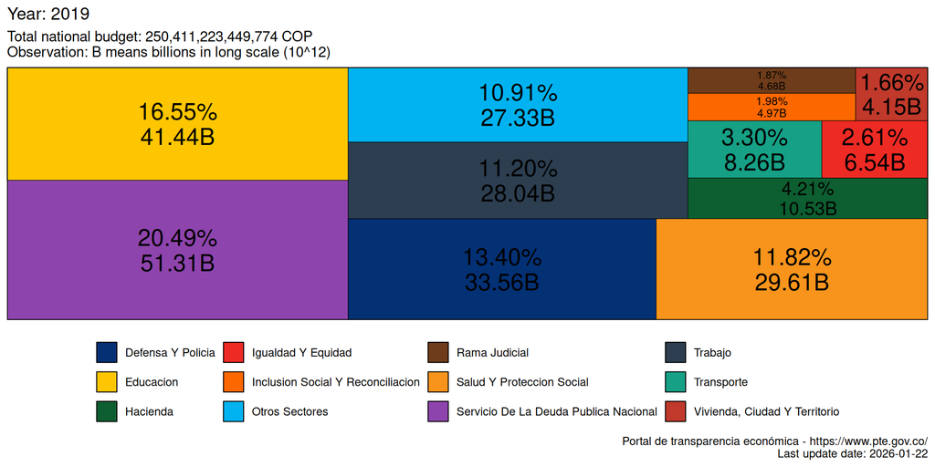

Figure 1: Who spent the nation’s general budget in 2019?

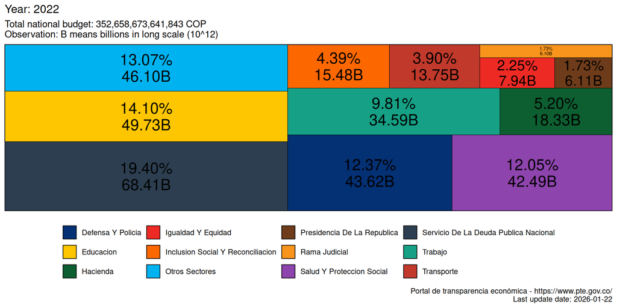

Figure 2: Who spent the nation’s general budget in 2022?

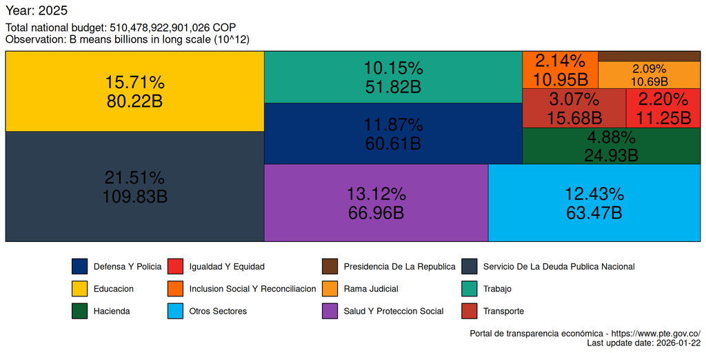

Figure 3: Who spent the nation’s general budget in 2025?

# Case study: Education sector

- Resources assigned to the Education sector in the year 2025 according to the **Presupuesto General de la Nación**
  - 80,217,122,200,378 COP
- Number of entities in the Education sector in the year 2025 according to the **Presupuesto General de la Nación**
  - 41

Table 3: Participation in the resources assigned for each entity in the education sector (Year 2025)

| Entity | Percentage participation in the resources assigned |
| --- | --- |
| Ministerio Educacion Nacional - Gestion General | 86.78 % |
| Unidad Administrativa Especial De Alimentacion Escolar | 2.74 % |
| Universidades Publicas - Universidad Nacional De Colombia | 2.08 % |
| Universidades Públicas - Universidad De Antioquia | 0.96 % |
| Universidades Públicas - Universidad Del Valle | 0.67 % |
| Universidades Publicas - Universidad Nacional Abierta Y A Distancia Unad | 0.58 % |
| Universidades Publicas - Universidad Pedagogica Y Tecnologica De Colombia | 0.40 % |
| Universidades Públicas - Universidad Industrial De Santander | 0.40 % |
| Universidades Publicas - Universidad Tecnologica De Pereira | 0.35 % |
| Universidades Públicas - Universidad Del Atlántico | 0.35 % |
| Universidades Publicas - Universidad Del Cauca | 0.32 % |
| Universidades Públicas - Universidad De Cartagena | 0.28 % |
| Universidades Publicas - Universidad De Caldas | 0.27 % |
| Universidades Publicas - Universidad De Cordoba | 0.26 % |
| Universidades Públicas - Universidad Del Magdalena | 0.25 % |
| Universidades Publicas - Universidad Pedagogica Nacional | 0.24 % |
| Universidades Públicas - Universidad De Nariño | 0.22 % |
| Universidades Públicas - Universidad De Pamplona | 0.22 % |
| Universidades Públicas - Universidad Militar Nueva Granada | 0.22 % |
| Universidades Públicas - Universidad Del Tolima | 0.21 % |
| Universidades Públicas - Universidad Del Quindío | 0.20 % |

Table 4: Participation in the resources assigned for each entity in the education sector (Year 2025)

| Entity | Percentage participation in the resources assigned |
| --- | --- |
| Universidades Publicas - Universidad Surcolombiana | 0.19 % |
| Universidades Publicas - Universidad Tecnologica Del Choco Diego Luis Cordoba | 0.17 % |
| Universidades Publicas - Universidad Popular Del Cesar | 0.15 % |
| Universidades Públicas - Universidad De La Guajira | 0.14 % |
| Universidades Públicas - Universidad Francisco De Paula Santander | 0.14 % |
| Universidades Publicas - Universidad De La Amazonia | 0.13 % |
| Universidades Publicas - Universidad De Los Llanos | 0.12 % |
| Universidades Publicas - Universidad Colegio Mayor De Cundinamarca | 0.11 % |
| Universidades Públicas - Universidad De Sucre | 0.11 % |
| Universidades Públicas - Universidad Distrital Francisco Jose De Caldas | 0.11 % |
| Universidades Públicas - Universidad Francisco De Paula Santander Seccional Ocaña | 0.11 % |
| Universidades Públicas - Universidad De Cundinamarca | 0.10 % |
| Escuela Tecnologica Instituto Tecnico Central | 0.09 % |
| Universidades Publicas - Universidad Del Pacifico | 0.07 % |
| Universidades Públicas - Universidad Internacional Del Trópico Americano | 0.07 % |
| Instituto Tolimense De Formacion Tecnica Profesional | 0.05 % |
| Instituto Tecnico Nacional De Comercio Simon Rodriguez De Cali | 0.04 % |
| Instituto Nacional De Formacion Tecnica Profesional De San Juan Del Cesar | 0.03 % |
| Universidades Públicas - Universidad Autónoma Indígena Intercultural Uaiin Cric | 0.03 % |
| Instituto Nacional De Formacion Tecnica Profesional De San Andres Y Providencia | 0.02 % |

# Acknowledgments

- To my family that supports me
- To the taxpayers of Colombia and the [**UMNG students**](https://www.umng.edu.co/estudiante) who pay my salary
- To the [**Business Science**](https://www.business-science.io/) and [**R4DS Online Learning**](https://www.rfordatasci.com/) communities where I learn [**R**](https://www.r-project.org/about.html) and [**$\pi$-thon**](https://www.python.org/about/)
- To the [**R Core Team**](https://www.r-project.org/contributors.html), the creators of [**RStudio IDE**](https://posit.co/download/rstudio-desktop/), [**Positron**](https://positron.posit.co/), [**Quarto**](https://quarto.org/) and the authors and maintainers of the packages [**tidyverse**](https://CRAN.R-project.org/package=tidyverse), [**janitor**](https://CRAN.R-project.org/package=janitor), [**gt**](https://CRAN.R-project.org/package=gt), [**scales**](https://CRAN.R-project.org/package=scales), [**treemapify**](https://CRAN.R-project.org/package=treemapify) and [**tinytex**](https://CRAN.R-project.org/package=tinytex) for allowing me to access these tools without paying for a license

# References

Cardenas, M. (2020). *Introducción a la Economía Colombiana* (4th ed.). Alfaomega.

Universidad Javeriana, O. F. de la. (2018). *Guía ciudadana a la tributación y el gasto del Estado colombiano*. https://www.ofiscal.org/publicaciones